# Milestone report - Capstone Project

Coursera Data Science Specialization

Filipe Pais Lenfers

# Synopsis

The Capstone Project objetive is to build a predictive text model from [HC Corpora](http://www.corpora.heliohost.org) database. The model should suggest the next word based on the previous words used. The text documents are provided from diferent three web sources: blogs, twitter and news articles. This report demonstrates the preliminary exploration of the data and the possible ways to build the prediction algorithm.

# Exploratory Analisys

## Libraries

Libraries used in this study.

```r
library(stringi)
library(tm)
```

```r
library(RWeka)
library(ggplot2)
library(dplyr)
```

## Obtaining the data

The data has been download from this link: https://d396qusza40orc.cloudfront.net/dsscapstone/dataset/Coursera-SwiftKey.zip, and uncompressed.

```r
destination.file <- "Coursera-SwiftKey.zip"
link <- "http://d396qusza40orc.cloudfront.net/dsscapstone/dataset/Coursera-SwiftKey.zip"

download.file(link, destination.file) #Download the data
unzip(destination.file) # Uncompress the data
file.rename("final","data") # Rename the final directory to data
```

There are four languages in this data set. On on each directory.

```r
list.files("data")
```

```
## [1] "de_DE" "en_US" "fi_FI" "ru_RU"
```

We will concetrate our analysis on the english data, there are 3 files from diferent sources in data:

```r
list.files("data/en_US")
```

```
## [1] "en_US.blogs.txt"   "en_US.news.txt"    "en_US.twitter.txt"
```

The source of the files are from:

- Blogs
- Newspappers
- Twitter

More details can be found in [HC Corpora](http://www.corpora.heliohost.org/aboutcorpus.html) website.

# Files Analysis

Lets load the three files to obtain some basic information about then.

```r
blog.file <- "data/en_US/en_US.blogs.txt"
twitter.file <- "data/en_US/en_US.twitter.txt"
news.file <- "data/en_US/en_US.news.txt"
blogs <- readLines(blog.file, encoding="UTF-8")
twitter <- readLines(twitter.file, encoding="UTF-8")
news  <- readLines(news.file, encoding="UTF-8")
```

Blog file:

- File name: data/en_US/en_US.blogs.txt.
- File size: 200.42 MB.
- Lines and chars statistics on the file:

```r
data.frame(t(stri_stats_general(blogs)))
```

```
##    Lines LinesNEmpty     Chars CharsNWhite
## 1 899288      899288 206824382   170389539
```

- Summary of the char quantities per line:

```r
summary(sapply(blogs,FUN=nchar))
```

```
##    Min. 1st Qu.  Median    Mean 3rd Qu.    Max.
##       1      47     156     230     329   40830
```

- Words count summary:

```r
summary(stri_count_words(blogs))
```

```
##    Min. 1st Qu.  Median    Mean 3rd Qu.    Max.
##    0.00    9.00   28.00   41.75   60.00 6726.00
```

Twitter file:

- File name: data/en_US/en_US.twitter.txt.
- File size: 159.36 MB.

```r
data.frame(t(stri_stats_general(twitter)))
```

```
##     Lines LinesNEmpty     Chars CharsNWhite
## 1 2360148     2360148 162096031   134082634
```

- Summary of the char quantities per line:

```r
summary(sapply(twitter,FUN=nchar))
```

```
##    Min. 1st Qu.  Median    Mean 3rd Qu.    Max.
##    2.00   37.00   64.00   68.68  100.00  140.00
```

- Words count summary:

```r
summary(stri_count_words(twitter))
```

```
##    Min. 1st Qu.  Median    Mean 3rd Qu.    Max.
##    1.00    7.00   12.00   12.75   18.00   47.00
```

News file:

- File name: data/en_US/en_US.news.txt.
- File size: 196.28 MB.

```r
data.frame(t(stri_stats_general(news)))
```

```
##     Lines LinesNEmpty     Chars CharsNWhite
## 1 1010242     1010242 203223154   169860866
```

- Summary of the char quantities per line:

```r
summary(sapply(news,FUN=nchar))
```

```
##    Min. 1st Qu.  Median    Mean 3rd Qu.    Max.
##     1.0   110.0   185.0   201.2   268.0 11380.0
```

- Words count summary:

```r
summary(stri_count_words(news))
```

```
##    Min. 1st Qu.  Median    Mean 3rd Qu.    Max.
##    1.00   19.00   32.00   34.41   46.00 1796.00
```

## Data Cleanning and Preprocessing

As we could see in the previous section the files are too big, so we will extract some samples to work with.

```r
sample.size <- 100000
```

```r
sample.blogs <- sample(blogs,sample.size)
sample.twitter <- sample(twitter,sample.size)
sample.news <- sample(news,sample.size)
```

- sample.blogs has 11.12% of the original data.
- sample.twitter has 4.24% of the original data.
- sample.news has 9.9% of the original data.

To garantie the reproducibility of this research we will save the samples and load then as needed.

```r
save(sample.blogs,sample.twitter,sample.news,file="samples.RData")
```

```r
load("samples.RData")
```

Lets convert the encoding of the characters, removing the non-convertible characters.

```r
sample.blogs <- iconv(sample.blogs, "latin1", "ASCII", sub="")
sample.twitter <- iconv(sample.twitter, "latin1", "ASCII", sub="")
sample.news <- iconv(sample.news, "latin1", "ASCII", sub="")
```

Now we need to clean the text, making all text lower case, removing pontuation, removing the number, removing the [stop words](http://en.wikipedia.org/wiki/Stop_words), removing profanities and striping the white spaces.We also (stem)[http://en.wikipedia.org/wiki/Stemming] the text. The list of profanity words was obtained from https://github.com/shutterstock/List-of-Dirty-Naughty-Obscene-and-Otherwise-Bad-Words/blob/master/en. This steps will make the data easier to analize.

```r
profanity.words <- readLines("en_profanity_words.txt")

corpus.blogs <- Corpus(VectorSource(list(sample.blogs)))
corpus.blogs <- tm_map(corpus.blogs, content_transformer(tolower))
corpus.blogs <- tm_map(corpus.blogs, content_transformer(removePunctuation))
corpus.blogs <- tm_map(corpus.blogs, content_transformer(removeNumbers))
corpus.blogs <- tm_map(corpus.blogs, removeWords, stopwords("english"))
corpus.blogs <- tm_map(corpus.blogs, removeWords, profanity.words)
corpus.blogs <- tm_map(corpus.blogs, stripWhitespace)

corpus.blogs <- tm_map(corpus.blogs, stemDocument, language='english')
```

```r
corpus.twitter <- Corpus(VectorSource(list(sample.twitter)))
corpus.twitter <- tm_map(corpus.twitter, content_transformer(tolower))
corpus.twitter <- tm_map(corpus.twitter, content_transformer(removePunctuation))
corpus.twitter <- tm_map(corpus.twitter, content_transformer(removeNumbers))
corpus.twitter <- tm_map(corpus.twitter, removeWords, stopwords("english"))
corpus.twitter <- tm_map(corpus.twitter, removeWords, profanity.words)
corpus.twitter <- tm_map(corpus.twitter, stripWhitespace)

corpus.twitter <- tm_map(corpus.twitter, stemDocument, language='english')
```

```r
corpus.news <- Corpus(VectorSource(list(sample.news)))
corpus.news <- tm_map(corpus.news, content_transformer(tolower))
corpus.news <- tm_map(corpus.news, content_transformer(removePunctuation))
corpus.news <- tm_map(corpus.news, content_transformer(removeNumbers))
corpus.news <- tm_map(corpus.news, removeWords, stopwords("english"))
corpus.news <- tm_map(corpus.news, removeWords, profanity.words)
corpus.news <- tm_map(corpus.news, stripWhitespace)

corpus.news <- tm_map(corpus.news, stemDocument, language='english')
```

The data is prepared to be analized.

## Data Analysis

To analize the samples we are going to do some [N-Grams](http://en.wikipedia.org/wiki/N-gram).

### Unigram analysis

With unigrams whe can check the works individualy, below we generate the unigrams and plot the top ten frequency of each sample.

#### Blogs

Top ten words:

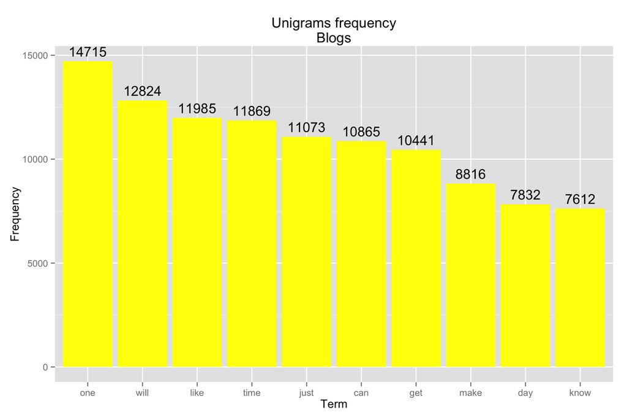

```r
UnigramTokenizer <- function(x) NGramTokenizer(x, Weka_control(min = 1, max = 1)) #Define the unigram function
unigram.termdocmatrix.blogs <- TermDocumentMatrix(corpus.blogs, control = list(tokenize = UnigramTokenizer)) #generate unigrams

unigram.df.blogs <- data.frame(Term = unigram.termdocmatrix.blogs$dimnames$Terms,
                                 Freq = unigram.termdocmatrix.blogs$v) #transform into dataframe
unigram.df.blogs <- unigram.df.blogs[order(unigram.df.blogs$Freq,decreasing = T),] # reorder dataframe

ggplot(head(unigram.df.blogs,10), aes(x=reorder(Term,-Freq), y=Freq)) +
  geom_bar(stat="Identity", fill="yellow") +
  geom_text(aes(label=Freq), vjust = -0.5) +
  ggtitle("Unigrams frequency\nBlogs") +
  ylab("Frequency") +
  xlab("Term")
```

- Whe have 80130 unique words on this sample.
- 45361 words occurs only one time.

How many words we need to cover 50% of the instances?

```r
cumsum.blogs <- cumsum(unigram.df.blogs$Freq)
limit.50.blogs <- sum(unigram.df.blogs$Freq)*0.5

length((cumsum.blogs[cumsum.blogs <=  limit.50.blogs]))
```

```
## [1] 548
```

How many word to cover 90% of the instances?

```r
limit.90.blogs <- sum(unigram.df.blogs$Freq)*0.9

length((cumsum.blogs[cumsum.blogs <=  limit.90.blogs]))
```

```
## [1] 6728
```

#### Twitter

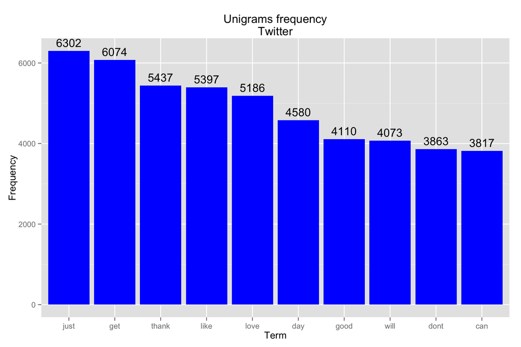

```r
unigram.termdocmatrix.twitter <- TermDocumentMatrix(corpus.twitter, control = list(tokenize = UnigramTokenizer)) #generate unigrams

unigram.df.twitter <- data.frame(Term = unigram.termdocmatrix.twitter$dimnames$Terms,
                                 Freq = unigram.termdocmatrix.twitter$v) #transform into dataframe
unigram.df.twitter <- unigram.df.twitter[order(unigram.df.twitter$Freq,decreasing = T),] # reorder dataframe

ggplot(head(unigram.df.twitter,10), aes(x=reorder(Term,-Freq), y=Freq)) +
  geom_bar(stat="Identity", fill="blue") +
  geom_text(aes(label=Freq), vjust = -0.5) +
  ggtitle("Unigrams frequency\nTwitter") +
  ylab("Frequency") +
  xlab("Term")
```

- Whe have 48711 unique words on this sample.
- 31084 words occurs only one time.

How many words we need to cover 50% of the instances?

```r
cumsum.twitter <- cumsum(unigram.df.twitter$Freq)
limit.50.twitter <- sum(unigram.df.twitter$Freq)*0.5

length((cumsum.twitter[cumsum.twitter <=  limit.50.twitter]))
```

```
## [1] 351
```

How many word to cover 90% of the instances?

```r
limit.90.twitter <- sum(unigram.df.twitter$Freq)*0.9

length((cumsum.twitter[cumsum.twitter <=  limit.90.twitter]))
```

```
## [1] 6312
```

#### News

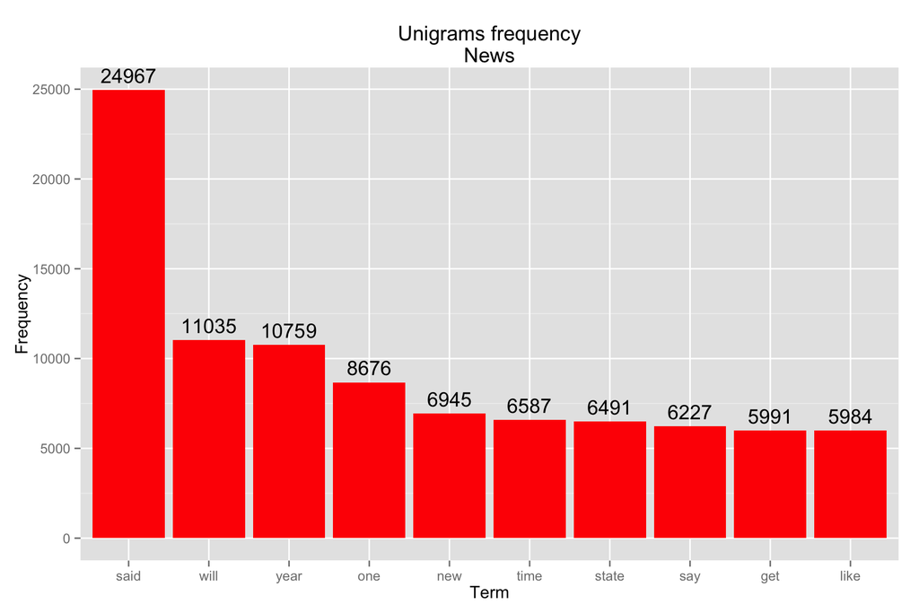

```r
unigram.termdocmatrix.news <- TermDocumentMatrix(corpus.news, control = list(tokenize = UnigramTokenizer)) #generate unigrams

unigram.df.news <- data.frame(Term = unigram.termdocmatrix.news$dimnames$Terms,
                                 Freq = unigram.termdocmatrix.news$v) #transform into dataframe
unigram.df.news <- unigram.df.news[order(unigram.df.news$Freq,decreasing = T),] # reorder dataframe

ggplot(head(unigram.df.news,10), aes(x=reorder(Term,-Freq), y=Freq)) +
  geom_bar(stat="Identity", fill="red") +
  geom_text(aes(label=Freq), vjust = -0.5) +
  ggtitle("Unigrams frequency\nNews") +
  ylab("Frequency") +
  xlab("Term")
```

- Whe have 72655 unique words on this sample.
- 36654 words occurs only one time.

How many words we need to cover 50% of the instances?

```r
cumsum.news <- cumsum(unigram.df.news$Freq)
limit.50.news <- sum(unigram.df.news$Freq)*0.5

length((cumsum.news[cumsum.news <=  limit.50.news]))
```

```
## [1] 662
```

How many word to cover 90% of the instances?

```r
limit.90.news <- sum(unigram.df.news$Freq)*0.9

length((cumsum.news[cumsum.news <=  limit.90.news]))
```

```
## [1] 7447
```

### Bigram analysis

Let’s analyze bigrams for the samples.

#### Blogs

Top ten words:

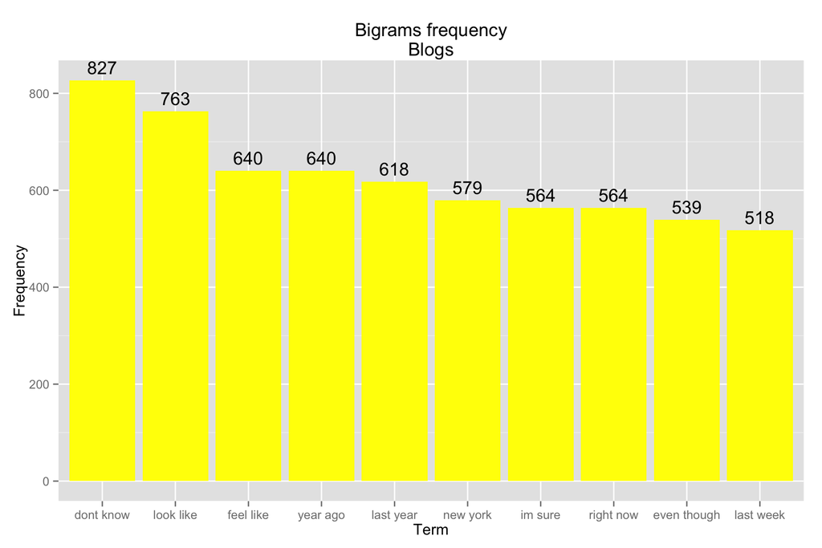

```r
BigramTokenizer <- function(x) NGramTokenizer(x, Weka_control(min = 2, max = 2)) #Define the bigram function
bigram.termdocmatrix.blogs <- TermDocumentMatrix(corpus.blogs, control = list(tokenize = BigramTokenizer)) #generate bigrams

bigram.df.blogs <- data.frame(Term = bigram.termdocmatrix.blogs$dimnames$Terms,
                                 Freq = bigram.termdocmatrix.blogs$v) #transform into dataframe
bigram.df.blogs <- bigram.df.blogs[order(bigram.df.blogs$Freq,decreasing = T),] # reorder dataframe

ggplot(head(bigram.df.blogs,10), aes(x=reorder(Term,-Freq), y=Freq)) +
  geom_bar(stat="Identity", fill="yellow") +
  geom_text(aes(label=Freq), vjust = -0.5) +
  ggtitle("Bigrams frequency\nBlogs") +
  ylab("Frequency") +
  xlab("Term")
```

- Whe have 1304798 unique bigrams on this sample.
- 1070341 bigrams occurs only one time.

How many bigrams we need to cover 50% of the instances?

```r
cumsum.blogs <- cumsum(bigram.df.blogs$Freq)
limit.50.blogs <- sum(bigram.df.blogs$Freq)*0.5

length((cumsum.blogs[cumsum.blogs <=  limit.50.blogs]))
```

```
## [1] 283863
```

How many bigrams to cover 90% of the instances?

```r
limit.90.blogs <- sum(bigram.df.blogs$Freq)*0.9

length((cumsum.blogs[cumsum.blogs <=  limit.90.blogs]))
```

```
## [1] 1100611
```

#### Twitter

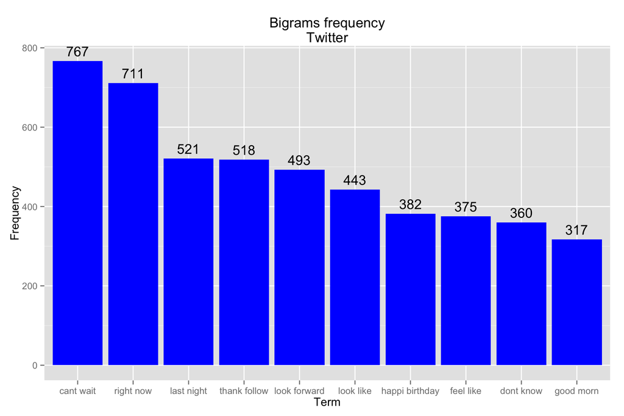

```r
bigram.termdocmatrix.twitter <- TermDocumentMatrix(corpus.twitter, control = list(tokenize = BigramTokenizer)) #generate bigrams

bigram.df.twitter <- data.frame(Term = bigram.termdocmatrix.twitter$dimnames$Terms,
                                 Freq = bigram.termdocmatrix.twitter$v) #transform into dataframe
bigram.df.twitter <- bigram.df.twitter[order(bigram.df.twitter$Freq,decreasing = T),] # reorder dataframe

ggplot(head(bigram.df.twitter,10), aes(x=reorder(Term,-Freq), y=Freq)) +
  geom_bar(stat="Identity", fill="blue") +
  geom_text(aes(label=Freq), vjust = -0.5) +
  ggtitle("Bigrams frequency\nTwitter") +
  ylab("Frequency") +
  xlab("Term")
```

- Whe have 426814 unique bigrams on this sample.
- 363868 bigrams occurs only one time.

How many bigrams we need to cover 50% of the instances?

```r
cumsum.twitter <- cumsum(bigram.df.twitter$Freq)
limit.50.twitter <- sum(bigram.df.twitter$Freq)*0.5

length((cumsum.twitter[cumsum.twitter <=  limit.50.twitter]))
```

```
## [1] 110077
```

How many bigrams to cover 90% of the instances?

```r
limit.90.twitter <- sum(bigram.df.twitter$Freq)*0.9

length((cumsum.twitter[cumsum.twitter <=  limit.90.twitter]))
```

```
## [1] 363466
```

#### News

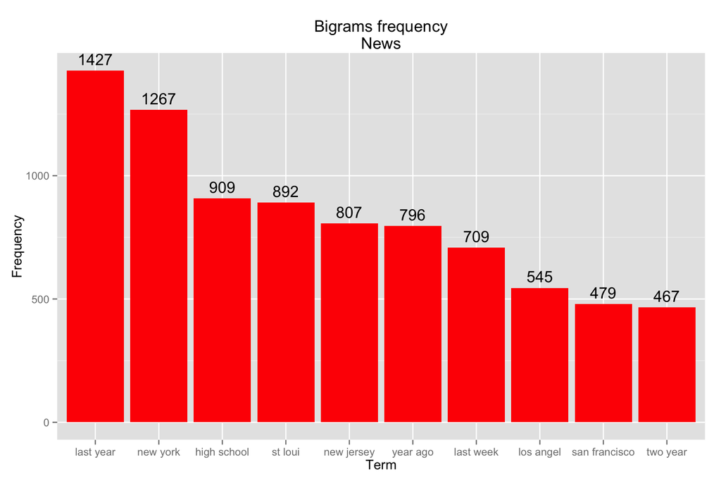

```r
bigram.termdocmatrix.news <- TermDocumentMatrix(corpus.news, control = list(tokenize = BigramTokenizer)) #generate bigrams

bigram.df.news <- data.frame(Term = bigram.termdocmatrix.news$dimnames$Terms,
                                 Freq = bigram.termdocmatrix.news$v) #transform into dataframe
bigram.df.news <- bigram.df.news[order(bigram.df.news$Freq,decreasing = T),] # reorder dataframe

ggplot(head(bigram.df.news,10), aes(x=reorder(Term,-Freq), y=Freq)) +
  geom_bar(stat="Identity", fill="red") +
  geom_text(aes(label=Freq), vjust = -0.5) +
  ggtitle("Bigrams frequency\nNews") +
  ylab("Frequency") +
  xlab("Term")
```

How many bigrams we need to cover 50% of the instances?

```r
cumsum.news <- cumsum(bigram.df.news$Freq)
limit.50.news <- sum(bigram.df.news$Freq)*0.5

length((cumsum.news[cumsum.news <=  limit.50.news]))
```

```
## [1] 271542
```

How many bigrams to cover 90% of the instances?

```r
limit.90.news <- sum(bigram.df.news$Freq)*0.9

length((cumsum.news[cumsum.news <=  limit.90.news]))
```

```
## [1] 1010446
```

# Next Steps

- Build a prection model
  - Research how to evaluate the model.
  - Test Markov chain and Naive Bayes.
  - Test other algorithms that can predict probability for more than one response, so we can offer alternatives to the user.
  - Consider the use of stopwords, maybe I want to predict some of then.
  - Consider when use punctuation, in cases such as “I’m”.
  - Consider to remove profanity after prediction, we can predict the profanity correctly but mask it after.
  - Use 2-gram, 3-gram, 4-gram and 5-gram to prectic the next word.
  - Use [Katz’s back-off model](http://en.wikipedia.org/wiki/Katz's_back-off_model).
  - Research how to predict a response when a word/N-gram was never seen in the data.
- Create shinny app
  - Consider the size in memory and performance (runtime) of the model.
  - Develop the app
  - Publish the app in shinyapps.io and check the resources consuption.
  - Let some friend test the app and give some feedback.
- Create a presentation of the product